# Predicción del Covid-19 Colombia

El presente estudio pretende analizar el comportamiento del Covid-19 en las 5 ciudades más afectas de Colomia a partir de los datos del portal de datos abiertos del gobierno colombiano tomando cada estado por separado, los infectados, recuperados, fallecidos y activos para realizar una prediccion al corto, mediano y largo plazo.

[Casos positivos de COVID-19 en Colombia](https://www.datos.gov.co/Salud-y-Protecci-n-Social/Casos-positivos-de-COVID-19-en-Colombia/gt2j-8ykr)

```python
#Importamos las librerias con las cuales se va a trabajar
import logging
logger = logging.getLogger()
logger.setLevel(logging.CRITICAL)

import pandas as pd
import numpy as np
import matplotlib.pyplot as plt
from scipy.integrate import odeint
from datetime import date, timedelta
from statsmodels import tools
```

## Lectura de datos

Se realiza la lectura directa de los datos utilizando Pandas y visualizamos los ultimos 5 registros

```python
df = pd.read_csv("https://www.datos.gov.co/api/views/gt2j-8ykr/rows.csv",sep = ',',thousands = None,decimal = '.')
df.tail()
```

|  | ID de caso | Fecha de notificación | Código DIVIPOLA | Ciudad de ubicación | Departamento o Distrito | atención | Edad | Sexo | Tipo | Estado | País de procedencia | FIS | Fecha de muerte | Fecha diagnostico | Fecha recuperado | fecha reporte web | Tipo recuperación | Codigo departamento | Codigo pais | Pertenencia etnica | Nombre grupo etnico |
| --- | --- | --- | --- | --- | --- | --- | --- | --- | --- | --- | --- | --- | --- | --- | --- | --- | --- | --- | --- | --- | --- |
| 607933 | 607974 | 2020-08-28T00:00:00.000 | 11001 | Bogotá D.C. | Bogotá D.C. | Casa | 50 | M | En estudio | Asintomático | NaN | Asintomático | NaN | 2020-08-30T00:00:00.000 | NaN | 2020-08-30T00:00:00.000 | NaN | 11 | NaN | NaN | NaN |
| 607934 | 607975 | 2020-08-29T00:00:00.000 | 11001 | Bogotá D.C. | Bogotá D.C. | Casa | 53 | F | En estudio | Asintomático | NaN | Asintomático | NaN | 2020-08-30T00:00:00.000 | NaN | 2020-08-30T00:00:00.000 | NaN | 11 | NaN | NaN | NaN |
| 607935 | 607976 | 2020-08-29T00:00:00.000 | 11001 | Bogotá D.C. | Bogotá D.C. | Casa | 48 | M | En estudio | Asintomático | NaN | Asintomático | NaN | 2020-08-30T00:00:00.000 | NaN | 2020-08-30T00:00:00.000 | NaN | 11 | NaN | NaN | NaN |
| 607936 | 607977 | 2020-08-29T00:00:00.000 | 11001 | Bogotá D.C. | Bogotá D.C. | Casa | 56 | M | En estudio | Asintomático | NaN | Asintomático | NaN | 2020-08-30T00:00:00.000 | NaN | 2020-08-30T00:00:00.000 | NaN | 11 | NaN | NaN | NaN |
| 607937 | 607978 | 2020-08-29T00:00:00.000 | 11001 | Bogotá D.C. | Bogotá D.C. | Casa | 49 | F | En estudio | Asintomático | NaN | Asintomático | NaN | 2020-08-30T00:00:00.000 | NaN | 2020-08-30T00:00:00.000 | NaN | 11 | NaN | NaN | NaN |

## Análisis de las columnas del dataset

Se chequean las columnas, el tipo de dato que infiere pandas y cuantos registros tienen valores diferente del nulo

```python
df.info()
```

```
<class 'pandas.core.frame.DataFrame'>
RangeIndex: 607938 entries, 0 to 607937
Data columns (total 21 columns):
 #   Column                    Non-Null Count   Dtype
---  ------                    --------------   -----
 0   ID de caso                607938 non-null  int64
 1   Fecha de notificación     607938 non-null  object
 2   Código DIVIPOLA           607938 non-null  int64
 3   Ciudad de ubicación       607938 non-null  object
 4   Departamento o Distrito   607938 non-null  object
 5   atención                  606687 non-null  object
 6   Edad                      607938 non-null  int64
 7   Sexo                      607938 non-null  object
 8   Tipo                      607938 non-null  object
 9   Estado                    606619 non-null  object
 10  País de procedencia       961 non-null     object
 11  FIS                       607938 non-null  object
 12  Fecha de muerte           20533 non-null   object
 13  Fecha diagnostico         604101 non-null  object
 14  Fecha recuperado          450626 non-null  object
 15  fecha reporte web         607938 non-null  object
 16  Tipo recuperación         450621 non-null  object
 17  Codigo departamento       607938 non-null  int64
 18  Codigo pais               962 non-null     float64
 19  Pertenencia etnica        281481 non-null  object
 20  Nombre grupo etnico       8139 non-null    object
dtypes: float64(1), int64(4), object(16)
memory usage: 97.4+ MB
```

## Selección de columnas de trabajo y enriquecimiento de información

Dado que el analisis se enfoca en el número de infectados, recuperados, fallecidos y activos, se descartan los atributos que no ayudan en la identificación del estado y se toman las fechas y el campo de ciudad.

Revisando la columna de atención en la cual se registran diferentes estados se determinó que la calidad es dudosa por lo cual se tomó la decisión de utilizar las fechas de recuperado y de muerte para realizar los respectivos conteos

```python
#Se revisan los registros sin valor para la columna de atención
df['atención'].isna().sum()
```

```
1251
```

## Revisión de la fecha de muerte

```python
df['Fecha de muerte'].value_counts().sort_index()
```

```
2020-03-16T00:00:00.000      1
2020-03-22T00:00:00.000      1
2020-03-23T00:00:00.000      1
2020-03-24T00:00:00.000      1
2020-03-25T00:00:00.000      4
                          ...
2020-08-26T00:00:00.000    198
2020-08-27T00:00:00.000    206
2020-08-28T00:00:00.000    173
2020-08-29T00:00:00.000    131
2020-08-30T00:00:00.000     23
Name: Fecha de muerte, Length: 163, dtype: int64
```

```python
df['Fecha de muerte'].isna().sum()
```

```
587405
```

No se ven valores extraños en las fechas y los valores nulos son normales en este campo

```python
#Minima fecha de muerte
df['Fecha de muerte'] = pd.to_datetime(df['Fecha de muerte'])
df['Fecha de muerte'].min()
```

```
Timestamp('2020-03-16 00:00:00')
```

Se registra la primera muerte el 16 de Marzo

```python
#Maxima fecha de muerte
df['Fecha de muerte'].max()
```

```
Timestamp('2020-08-30 00:00:00')
```

## Revisión de la fecha de recuperación

```python
df['Fecha recuperado'].value_counts().sort_index()
```

```
2020-03-13T00:00:00.000        1
2020-03-14T00:00:00.000        1
2020-03-15T00:00:00.000        1
2020-03-17T00:00:00.000        1
2020-03-19T00:00:00.000        1
                           ...
2020-08-26T00:00:00.000    11823
2020-08-27T00:00:00.000    10973
2020-08-28T00:00:00.000    12303
2020-08-29T00:00:00.000    11123
2020-08-30T00:00:00.000    10051
Name: Fecha recuperado, Length: 169, dtype: int64
```

```python
df['Fecha recuperado'].isna().sum()
```

```
157312
```

No se ven valores extraños en las fechas y los valores nulos son normales en este campo

```python
#Minima fecha de recuperado
df['Fecha recuperado'] = pd.to_datetime(df['Fecha recuperado'])
df['Fecha recuperado'].min()
```

```
Timestamp('2020-03-13 00:00:00')
```

Se registra el primer recuperado el 13 de Marzo

```python
#Maxima fecha de recuperado
df['Fecha recuperado'].max()
```

```
Timestamp('2020-08-30 00:00:00')
```

## Revisión de la fecha de inicio de síntomas

```python
df['FIS'].value_counts().head()
```

```
Asintomático               72136
2020-07-24T00:00:00.000    12530
2020-07-27T00:00:00.000    10946
2020-07-25T00:00:00.000    10144
2020-08-01T00:00:00.000     9630
Name: FIS, dtype: int64
```

Se evidencia que el campo de fecha de inicio de síntomas se está utilizando para marcar los casos de personas asintomaticas pero se pienza utilizar este campo para realizar los conteos de infecciones porlo cual es necesario hacer un tratamiento con los registros con el valor 'Asintomático'

Inicialmente convertimos los campos de fechas a tipo de dato fecha con el parametro de forzado lo cual nos generará unos valores NaT para los valores que no sean covnvertidos a fecha y posteriormente dichos valores se reemplazan con la fecha de reporte web

```python
df['Fecha de muerte'] = pd.to_datetime(df['Fecha de muerte'])
df['Fecha diagnostico'] = pd.to_datetime(df['Fecha diagnostico'])
df['FIS'] = pd.to_datetime(df['FIS'], errors="coerce") #Este campo tiene un registro con un valor que no corresponde
df['fecha reporte web'] = pd.to_datetime(df['fecha reporte web'])
df['Fecha de notificación'] = pd.to_datetime(df['Fecha de notificación'])
df['FIS'].fillna(df['fecha reporte web'], inplace=True)
```

Es necesario crear los campos de los contadores segun las columnas de fecha que tengan valores para poder realizar los conteos posteriormente.

```python
# Se crean los contadores
df["Casos"] = 1
df.loc[(df['Fecha de muerte'].notnull() == True), 'Muertos'] = 1
df['Muertos'].fillna(0, inplace = True)
df.loc[(df['Fecha recuperado'].notnull() == True), 'Recuperados'] = 1
df['Recuperados'].fillna(0, inplace = True)
df.loc[(~df['Fecha de muerte'].notnull() == True) & (~df['Fecha recuperado'].notnull() == True), 'Activos'] = 1
df['Activos'].fillna(0, inplace = True)

df.loc[(~df['Fecha de muerte'].notnull() == False) & (~df['Fecha recuperado'].notnull() == False), 'ERR'] = 1
df['ERR'].fillna(0, inplace = True)
```

## Validación de conteos

```python
df.groupby(["Ciudad de ubicación"]).agg({'Casos': 'sum', 'Recuperados': 'sum', 'Activos': 'sum', 'Muertos': 'sum'}).sort_values(ascending=False, by="Casos").head()
```

| Ciudad de ubicación | Casos | Recuperados | Activos | Muertos |
| --- | --- | --- | --- | --- |
| Bogotá D.C. | 209250 | 148541.0 | 55050.0 | 5715.0 |
| Medellín | 46361 | 34501.0 | 10910.0 | 953.0 |
| Cali | 36555 | 28392.0 | 6855.0 | 1312.0 |
| Barranquilla | 36069 | 32744.0 | 1652.0 | 1688.0 |
| Cartagena de Indias | 20359 | 18296.0 | 1523.0 | 547.0 |

Se puede ver que con la estructura anterior las sumas de activos + recuperados + muertos no dan el total de casos de cada ciudad por lo cual se realiza una validación adicional y se encuentra que hay registros que tienen tanto fecha de recuperado como fecha de muerte.

```python
df.loc[(~df['Fecha de muerte'].notnull() == False) & (~df['Fecha recuperado'].notnull() == False), 'ERR'] = 1
df['ERR'].fillna(0, inplace = True)
grupos = df.groupby(["Ciudad de ubicación"]).agg({'Casos': 'sum', 'Recuperados': 'sum', 'Activos': 'sum', 'Muertos': 'sum','ERR':'sum'}).sort_values(ascending=False, by="Casos").head()
grupos
```

| Ciudad de ubicación | Casos | Recuperados | Activos | Muertos | ERR |
| --- | --- | --- | --- | --- | --- |
| Bogotá D.C. | 209250 | 148541.0 | 55050.0 | 5715.0 | 56.0 |
| Medellín | 46361 | 34501.0 | 10910.0 | 953.0 | 3.0 |
| Cali | 36555 | 28392.0 | 6855.0 | 1312.0 | 4.0 |
| Barranquilla | 36069 | 32744.0 | 1652.0 | 1688.0 | 15.0 |
| Cartagena de Indias | 20359 | 18296.0 | 1523.0 | 547.0 | 7.0 |

En la limpieza de datos se utilizará el valor de la columna atención para determinar si el registro corresponde a un recuperado o a un muerto y en caso de no poderlo determinar se borrará el registro.

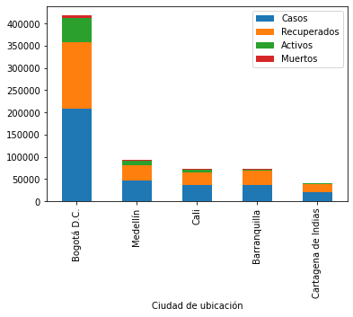

```python
grupos[['Casos','Recuperados','Activos','Muertos']].plot(kind='bar', stacked=True)
```

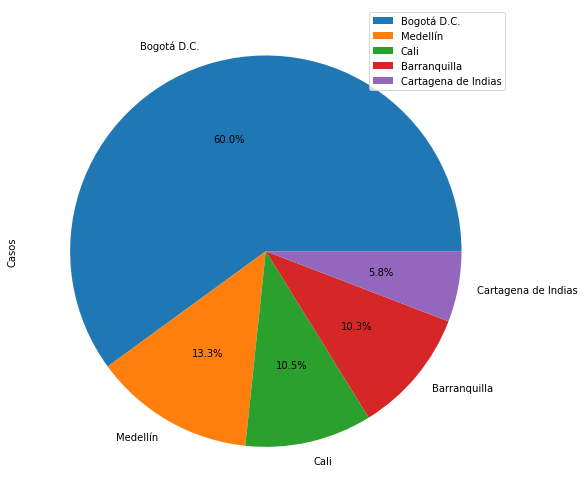

```python
grupos.plot.pie(y='Casos', figsize=(9, 9), autopct='%1.1f%%')
```

## Ciudades

Las 5 ciudades con mas casos son:

- Bogotá D.C.
- Medellín
- Barranquilla
- Cali
- Cartagena de Indias

```python
ciudades = ["Bogotá D.C.", "Medellín","Barranquilla", "Cali", "Cartagena de Indias"]
```

Se realiza agrupamiento por ciudad y fecha de inicio de sintomas (FIS)

```python
df_1 = df[df["Ciudad de ubicación"].isin(ciudades)].groupby(["Ciudad de ubicación", "FIS"]).agg({'Casos': 'sum', 'Recuperados': 'sum', 'Activos': 'sum', 'Muertos': 'sum'}).reset_index()
df_1
```

|  | Ciudad de ubicación | FIS | Casos | Recuperados | Activos | Muertos |
| --- | --- | --- | --- | --- | --- | --- |
| 0 | Barranquilla | 2020-03-06 | 2 | 2.0 | 0.0 | 0.0 |
| 1 | Barranquilla | 2020-03-09 | 2 | 2.0 | 0.0 | 0.0 |
| 2 | Barranquilla | 2020-03-10 | 2 | 2.0 | 0.0 | 0.0 |
| 3 | Barranquilla | 2020-03-12 | 2 | 2.0 | 0.0 | 0.0 |
| 4 | Barranquilla | 2020-03-13 | 2 | 2.0 | 0.0 | 0.0 |
| ... | ... | ... | ... | ... | ... | ... |
| 986 | Medellín | 2020-08-25 | 113 | 0.0 | 112.0 | 1.0 |
| 987 | Medellín | 2020-08-26 | 96 | 0.0 | 95.0 | 1.0 |
| 988 | Medellín | 2020-08-27 | 56 | 0.0 | 56.0 | 0.0 |
| 989 | Medellín | 2020-08-28 | 41 | 0.0 | 41.0 | 0.0 |
| 990 | Medellín | 2020-08-29 | 2 | 0.0 | 2.0 | 0.0 |

991 rows × 6 columns

```
Ciudad de ubicación
Barranquilla           AxesSubplot(0.125,0.2;0.775x0.68)
Bogotá D.C.            AxesSubplot(0.125,0.2;0.775x0.68)
Cali                   AxesSubplot(0.125,0.2;0.775x0.68)
Cartagena de Indias    AxesSubplot(0.125,0.2;0.775x0.68)
Medellín               AxesSubplot(0.125,0.2;0.775x0.68)
Name: Casos, dtype: object
```

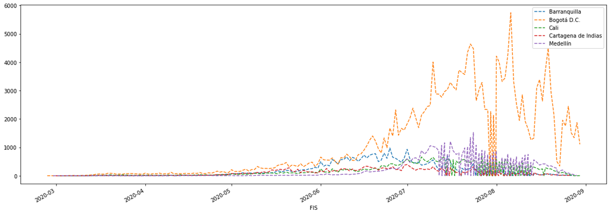

```python
fig, ax = plt.subplots(figsize=(20,7))
df_1.set_index("FIS").groupby(["Ciudad de ubicación"])['Casos'].plot(legend = True, ls='--')
```

```
Ciudad de ubicación
Barranquilla           AxesSubplot(0.125,0.2;0.775x0.68)
Bogotá D.C.            AxesSubplot(0.125,0.2;0.775x0.68)
Cali                   AxesSubplot(0.125,0.2;0.775x0.68)
Cartagena de Indias    AxesSubplot(0.125,0.2;0.775x0.68)
Medellín               AxesSubplot(0.125,0.2;0.775x0.68)
Name: Recuperados, dtype: object
```

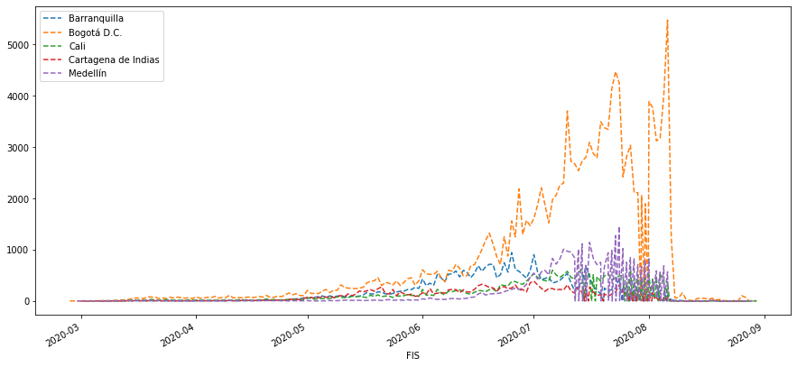

```python
fig, ax = plt.subplots(figsize=(15,7))
df_1.set_index("FIS").groupby(["Ciudad de ubicación"])['Recuperados'].plot(legend = True, ls='--')
```

```
Ciudad de ubicación
Barranquilla           AxesSubplot(0.125,0.2;0.775x0.68)
Bogotá D.C.            AxesSubplot(0.125,0.2;0.775x0.68)
Cali                   AxesSubplot(0.125,0.2;0.775x0.68)
Cartagena de Indias    AxesSubplot(0.125,0.2;0.775x0.68)
Medellín               AxesSubplot(0.125,0.2;0.775x0.68)
Name: Activos, dtype: object
```

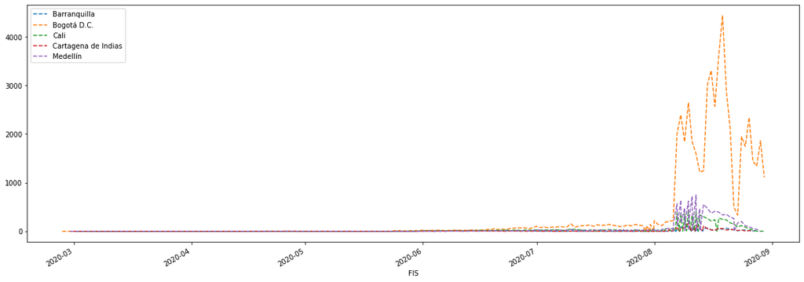

```python
fig, ax = plt.subplots(figsize=(20,7))
df_1.set_index("FIS").groupby(["Ciudad de ubicación"])['Activos'].plot(legend = True, ls='--')
```